# Linear Regression

2019-10-07

Install any of these packages if you don’t have them.

```r
library(readr) #importing data
library(janitor) #mainly clean_names function
library(dplyr) #for manipulating data
library(ggplot2) #for plotting
library(broom) #for dealing with lm output
```

Your very own linear regression sampler:

[figure not shown]

A place for you to save useful R code snippets, notes to yourself, and anything you want to be able to remember the next time you need to conduct a linear regression analysis.

Using our advertising data, suppose we wish to model the linear relationship between the TV budget and sales.

$$Y = \beta_0 + \beta_1X + \epsilon \tag{1}$$

where:

- Y represents sales
- X represents TV advertising budget
- $\beta_0$ is the intercept
- $\beta_1$ is the coefficient (slope term) representing the linear relationship
- $\epsilon$ is a mean-zero random error term

NOTE: equations are auto numbered!

# Read in the advertising data

```r
ad <- read_csv("http://faculty.marshall.usc.edu/gareth-james/ISL/Advertising.csv") %>%
  clean_names() %>%
  select(-x1)
# Look at the object in the Environment tab - Why the "cols()" output?
```

# Explore dataset

```r
# SO many options
glimpse(ad)
```

```
## Observations: 200
## Variables: 4
## $ tv        <dbl> 230.1, 44.5, 17.2, 151.5, 180.8, 8.7, 57.5, 120.2, 8...
## $ radio     <dbl> 37.8, 39.3, 45.9, 41.3, 10.8, 48.9, 32.8, 19.6, 2.1,...
## $ newspaper <dbl> 69.2, 45.1, 69.3, 58.5, 58.4, 75.0, 23.5, 11.6, 1.0,...
## $ sales     <dbl> 22.1, 10.4, 9.3, 18.5, 12.9, 7.2, 11.8, 13.2, 4.8, 1...
```

```r
head(ad)
```

```
## # A tibble: 6 x 4
##      tv radio newspaper sales
##   <dbl> <dbl>     <dbl> <dbl>
## 1 230.   37.8      69.2  22.1
## 2  44.5  39.3      45.1  10.4
## 3  17.2  45.9      69.3   9.3
## 4 152.   41.3      58.5  18.5
## 5 181.   10.8      58.4  12.9
## 6   8.7  48.9      75     7.2
```

```r
tail(ad, n=10)
```

```
## # A tibble: 10 x 4
##       tv radio newspaper sales
##    <dbl> <dbl>     <dbl> <dbl>
##  1  39.5  41.1       5.8  10.8
##  2  75.5  10.8       6     9.9
##  3  17.2   4.1      31.6   5.9
##  4 167.   42         3.6  19.6
##  5 150.   35.6       6    17.3
##  6  38.2   3.7      13.8   7.6
##  7  94.2   4.9       8.1   9.7
##  8 177     9.3       6.4  12.8
##  9 284.   42        66.2  25.5
## 10 232.    8.6       8.7  13.4
```

```r
skimr::skim(ad) #What's with the '::'
```

```
## Skim summary statistics
##  n obs: 200
##  n variables: 4
##
## -- Variable type:numeric ---------------------------------------------------------------------------------------------------
##   variable missing complete   n   mean    sd  p0   p25    p50    p75  p100
##  newspaper       0      200 200  30.55 21.78 0.3 12.75  25.75  45.1  114
##      radio       0      200 200  23.26 14.85 0    9.97  22.9   36.52  49.6
##      sales       0      200 200  14.02  5.22 1.6 10.38  12.9   17.4   27
##         tv       0      200 200 147.04 85.85 0.7 74.38 149.75 218.82 296.4
##      hist
##  ▇▇▅▅▂▁▁▁
##  ▇▆▅▅▆▅▆▅
##  ▁▃▇▇▆▃▃▂
##  ▆▅▆▅▅▇▆▅
```

# Make a scatterplot

Traditionally, the response variable (Y) goes on the y-axis, and the predictor variable (X) goes on the x-axis.

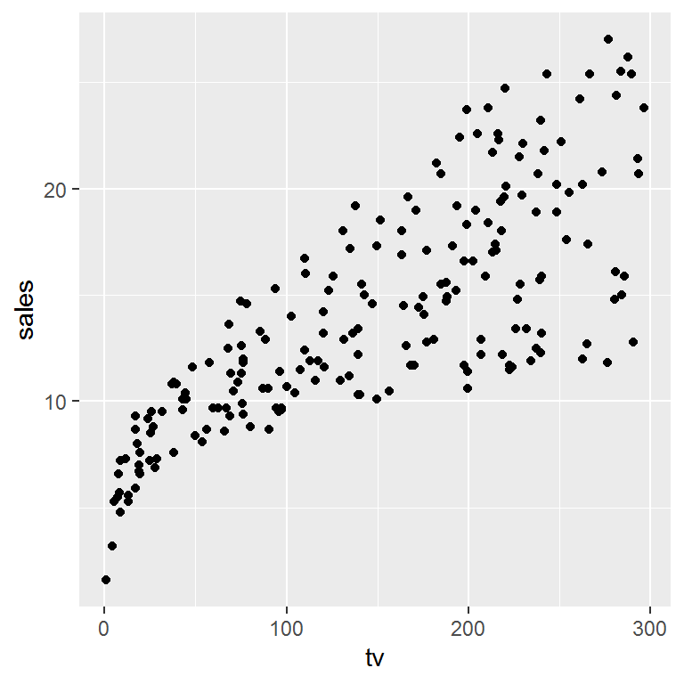

```r
adplot <- ggplot(ad,aes(x=tv, y=sales)) +
  geom_point()
adplot
```

```r
# What if I don't specifiy the variables in aes()? What if no "geom_?"
```

Is there a relationship between TV advertising budgets and sales?

# Find the correlation

```r
ad %>%
  dplyr::summarize(pearson = cor(sales,tv))
```

```
## # A tibble: 1 x 1
##   pearson
##     <dbl>
## 1   0.782
```

Would you quantify the value of correlation calculated above as being:

- strongly positively linear,
- weakly positively linear,
- not linear,
- weakly negatively linear, or
- strongly positively linear?

# Add regression line to scatterplot

You can visualize the linear regression model by adding another geom, `geom_smooth()` to your scatterplot.

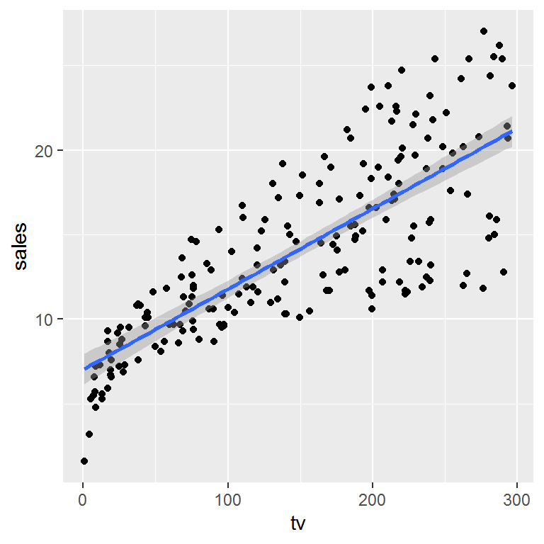

```r
adplot + geom_smooth(method = "lm")
```

Note that the gray region shows the confidence interval around the line. Call the help function `?geom_smooth` and figure out how to turn this off:

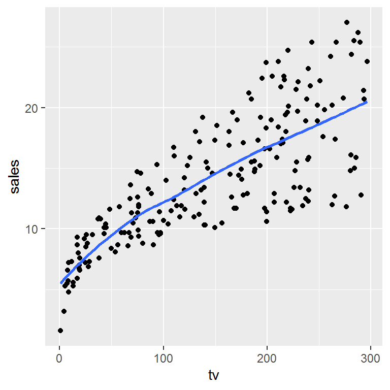

```r
# your code goes here
adplot + geom_smooth(se=FALSE)
```

Now see what happens when you take away the `method = "lm"` argument (so there is nothing inside the parentheses).

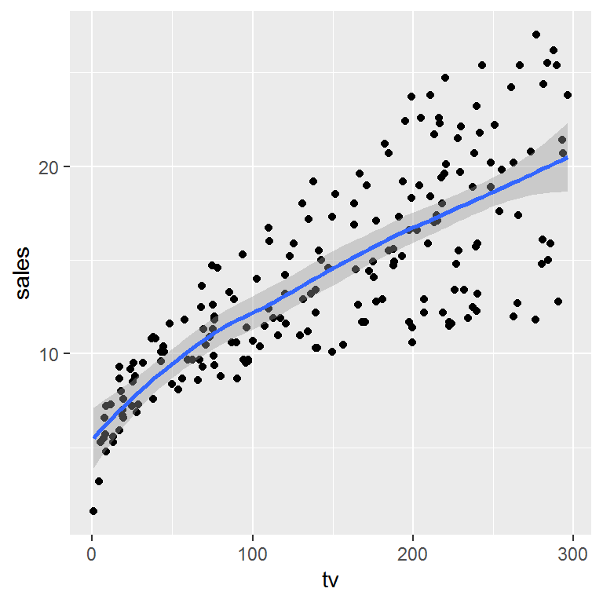

```r
adplot <- ggplot(ad,aes(x=tv, y=sales)) +
  geom_point() +
  geom_smooth()
adplot
```

Call the help function `?geom_smooth` and figure out the default setting for the `method` argument. What kind of method is this geom using to create the line you see in the code above?

# Build a linear regression model

```r
admod <- lm(sales ~ tv, data = ad)
```

Print that object by calling `admod`, and use the `summary()` function also. What are you looking at?

```r
summary(admod)
```

```
##
## Call:
## lm(formula = sales ~ tv, data = ad)
##
## Residuals:
##     Min      1Q  Median      3Q     Max
## -8.3860 -1.9545 -0.1913  2.0671  7.2124
##
## Coefficients:
##             Estimate Std. Error t value Pr(>|t|)
## (Intercept) 7.032594   0.457843   15.36   <2e-16 ***
## tv          0.047537   0.002691   17.67   <2e-16 ***
## ---
## Signif. codes:  0 '***' 0.001 '**' 0.01 '*' 0.05 '.' 0.1 ' ' 1
##
## Residual standard error: 3.259 on 198 degrees of freedom
## Multiple R-squared:  0.6119, Adjusted R-squared:  0.6099
## F-statistic: 312.1 on 1 and 198 DF,  p-value: < 2.2e-16
```

Note that this output is not very “tidy”. What different “sections” of output do you see?

[your answer goes here:]

1. formula
2. Residuals
3. Coefficients
4. Model level statistics

We’ll come back to this topic later.

# Examine the model statistics

Use `broom::glance` to examine the model statistics like $R^2$, the F-statistic, etc. Here, there is one row for each model so it is *tidy*.

```r
glance(admod)
```

```
## # A tibble: 1 x 11
##   r.squared adj.r.squared sigma statistic  p.value    df logLik   AIC   BIC
##       <dbl>         <dbl> <dbl>     <dbl>    <dbl> <int>  <dbl> <dbl> <dbl>
## 1     0.612         0.610  3.26      312. 1.47e-42     2  -519. 1044. 1054.
## # ... with 2 more variables: deviance <dbl>, df.residual <int>
```

Go back to the output from the `summary()` function: how does the output of `broom::glance()` differ from that of `summary()`?

# Examine the model components

Use `broom::tidy` to examine the model components like coefficients and their p-values. Here, each row corresponds to a coefficient (the intercept term + predictors) so it is *tidy*.

```r
tidy(admod)
```

```
## # A tibble: 2 x 5
##   term        estimate std.error statistic  p.value
##   <chr>          <dbl>     <dbl>     <dbl>    <dbl>
## 1 (Intercept)   7.03     0.458        15.4 1.41e-35
## 2 tv            0.0475   0.00269      17.7 1.47e-42
```

Go back to the output from the `summary()` function: how does the output of `broom::tidy()` differ from that of `summary()`?

# Examine the observations

Use `broom::augment` to examine the observation-level statistics like fitted values, residuals, etc. Here, each row is an observation in the original dataset so it is *tidy*.

```r
augment(admod)
```

```
## # A tibble: 200 x 9
##    sales    tv .fitted .se.fit .resid    .hat .sigma   .cooksd .std.resid
##    <dbl> <dbl>   <dbl>   <dbl>  <dbl>   <dbl>  <dbl>     <dbl>      <dbl>
##  1  22.1 230.    18.0    0.321  4.13  0.00970   3.25 0.00794       1.27
##  2  10.4  44.5    9.15   0.359  1.25  0.0122    3.27 0.000920      0.387
##  3   9.3  17.2    7.85   0.419  1.45  0.0165    3.27 0.00169       0.449
##  4  18.5 152.    14.2    0.231  4.27  0.00501   3.25 0.00434       1.31
##  5  12.9 181.    15.6    0.248 -2.73  0.00578   3.26 0.00205      -0.839
##  6   7.2   8.7    7.45   0.438 -0.246 0.0180    3.27 0.0000534    -0.0762
##  7  11.8  57.5    9.77   0.333  2.03  0.0105    3.26 0.00208       0.627
##  8  13.2 120.    12.7    0.241  0.454 0.00549   3.27 0.0000538     0.140
##  9   4.8   8.6    7.44   0.438 -2.64  0.0181    3.26 0.00616      -0.818
## 10  10.6 200.    16.5    0.271 -5.93  0.00690   3.24 0.0116       -1.83
## # ... with 190 more rows
```

This probably printed something very long to your console.

Try piping this output to the `head()` function to see the first 6 rows.

```r
augment(admod) %>%
  head()# your code goes here
```

```
## # A tibble: 6 x 9
##   sales    tv .fitted .se.fit .resid    .hat .sigma   .cooksd .std.resid
##   <dbl> <dbl>   <dbl>   <dbl>  <dbl>   <dbl>  <dbl>     <dbl>      <dbl>
## 1  22.1 230.    18.0    0.321  4.13  0.00970   3.25 0.00794       1.27
## 2  10.4  44.5    9.15   0.359  1.25  0.0122    3.27 0.000920      0.387
## 3   9.3  17.2    7.85   0.419  1.45  0.0165    3.27 0.00169       0.449
## 4  18.5 152.    14.2    0.231  4.27  0.00501   3.25 0.00434       1.31
## 5  12.9 181.    15.6    0.248 -2.73  0.00578   3.26 0.00205      -0.839
## 6   7.2   8.7    7.45   0.438 -0.246 0.0180    3.27 0.0000534    -0.0762
```

Now save the augmented dataframe to a new object called `admod_aug`

```r
admod_aug <- admod %>%
  augment()
      # your code goes here
```

# Plot the residuals

In general you’d like your residuals to look symmetrically distributed (e.g. approximately Normally).

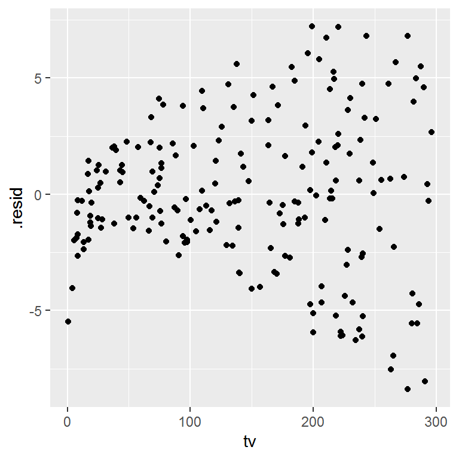

```r
ggplot(admod_aug, aes(x = tv, y = .resid)) +
  geom_point()
```

But they aren’t in this case. Outliers in the residuals aren’t great either. What do you think? Is this a good candidate for linear regression?

Another way to see the relationship

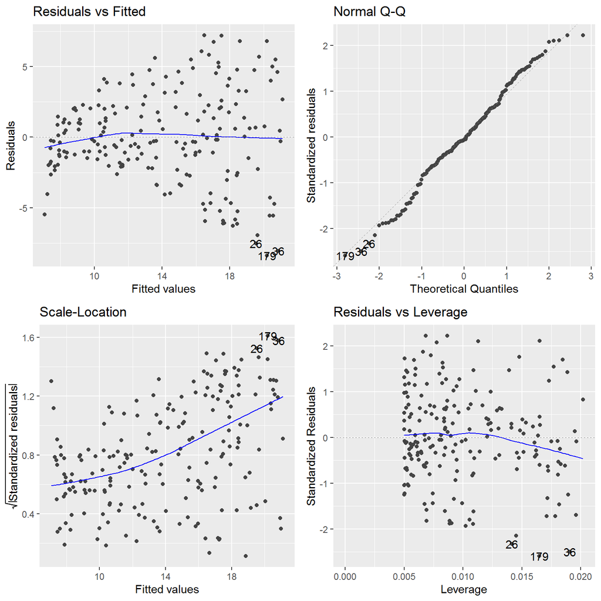

```r
library(ggfortify)
autoplot(admod)
```

```r
# Notice the x-axis on the first chart. Above we put `tv` on the x-axis.
# Why are both ways reasonable?
```

# If we have time:

1. Compute the SS’s
2. Compute $R^2$
3. glance the linear model - do the $R^2$ values match?
4. Describe what the $R^2$ tells us.

```r
admod_aug %>%
  summarize(SST = sum((sales - mean(sales))^2),
         SSR = sum((sales - .fitted)^2),
         SSM = sum((.fitted - mean(sales))^2),
         R2 = SSM/SST
         )
```

```
## # A tibble: 1 x 4
##     SST   SSR   SSM    R2
##   <dbl> <dbl> <dbl> <dbl>
## 1 5417. 2103. 3315. 0.612
```

```r
glance(admod)
```

```
## # A tibble: 1 x 11
##   r.squared adj.r.squared sigma statistic  p.value    df logLik   AIC   BIC
##       <dbl>         <dbl> <dbl>     <dbl>    <dbl> <int>  <dbl> <dbl> <dbl>
## 1     0.612         0.610  3.26      312. 1.47e-42     2  -519. 1044. 1054.
## # ... with 2 more variables: deviance <dbl>, df.residual <int>
```

# Build an intercept-only model and compare models

```r
intmod <- lm(sales ~ 1, data = ad)
```

Print that object, and use the `summary()` function also. What do you see?

```r
# your code goes here
intmod
```

```
##
## Call:
## lm(formula = sales ~ 1, data = ad)
##
## Coefficients:
## (Intercept)
##       14.02
```

```r
summary(intmod)
```

```
##
## Call:
## lm(formula = sales ~ 1, data = ad)
##
## Residuals:
##     Min      1Q  Median      3Q     Max
## -12.422  -3.647  -1.123   3.377  12.977
##
## Coefficients:
##             Estimate Std. Error t value Pr(>|t|)
## (Intercept)  14.0225     0.3689   38.01   <2e-16 ***
## ---
## Signif. codes:  0 '***' 0.001 '**' 0.01 '*' 0.05 '.' 0.1 ' ' 1
##
## Residual standard error: 5.217 on 199 degrees of freedom
```

Now compare the intercept-only model object to your model that included TV advertising budget as a predictor (`admod`) using the `anova()` function. What do you see? Compare to the output of `summary(admod)`- what do you notice?

```r
# your code goes here
anova(intmod, admod) #The model with fewer predictors goes first
```

```
## Analysis of Variance Table
##
## Model 1: sales ~ 1
## Model 2: sales ~ tv
##   Res.Df    RSS Df Sum of Sq      F    Pr(>F)
## 1    199 5417.1
## 2    198 2102.5  1    3314.6 312.14 < 2.2e-16 ***
## ---
## Signif. codes:  0 '***' 0.001 '**' 0.01 '*' 0.05 '.' 0.1 ' ' 1
```

```r
summary(admod)
```

```
##
## Call:
## lm(formula = sales ~ tv, data = ad)
##
## Residuals:
##     Min      1Q  Median      3Q     Max
## -8.3860 -1.9545 -0.1913  2.0671  7.2124
##
## Coefficients:
##             Estimate Std. Error t value Pr(>|t|)
## (Intercept) 7.032594   0.457843   15.36   <2e-16 ***
## tv          0.047537   0.002691   17.67   <2e-16 ***
## ---
## Signif. codes:  0 '***' 0.001 '**' 0.01 '*' 0.05 '.' 0.1 ' ' 1
##
## Residual standard error: 3.259 on 198 degrees of freedom
## Multiple R-squared:  0.6119, Adjusted R-squared:  0.6099
## F-statistic: 312.1 on 1 and 198 DF,  p-value: < 2.2e-16
```